# Assignment 9: Visualization - Revealing a graph

*How to do it?*:

- Open the Rmarkdown file of this assignment (link) in Rstudio.
- Right under each **question**, insert a code chunk (you can use the hotkey `Ctrl + Alt + I` to add a code chunk) and code the solution for the question.
- `Knit` the rmarkdown file (hotkey: `Ctrl + Alt + K`) to export an html.
- Publish the html file to your Githiub Page.

*Submission*: Submit the link on Github of the assignment to Blackboard.

1. Use the dataset by of covid 19 by WHO at https://covid19.who.int/WHO-COVID-19-global-data.csv. Find the three countries with the most numbers of deaths by Covid-19.

Hint:

- Use `filter` to select the most current date
- Pipe with `arrange(-Cumulative_deaths)` to rank the data by the number of cumulative deaths

```r
library(tidyverse)
#Dataset
df = read_csv('https://covid19.who.int/WHO-COVID-19-global-data.csv')
#Find top countries
df1 = df %>% filter(Date_reported == max(Date_reported)) %>% arrange(-Cumulative_deaths)
#Top three countries isolated
df1 = head(df1['Country'],3)
#Create top three countries list
top_three = c(df1 %>% slice(1),df1 %>% slice(2),df1 %>% slice(3))
#List to be used to filter
print(top_three)
```

```
## $Country
## [1] "United States of America"
##
## $Country
## [1] "Brazil"
##
## $Country
## [1] "India"
```

2. Make a plot revealing the number of deaths in the three countries with the most numbers of deaths

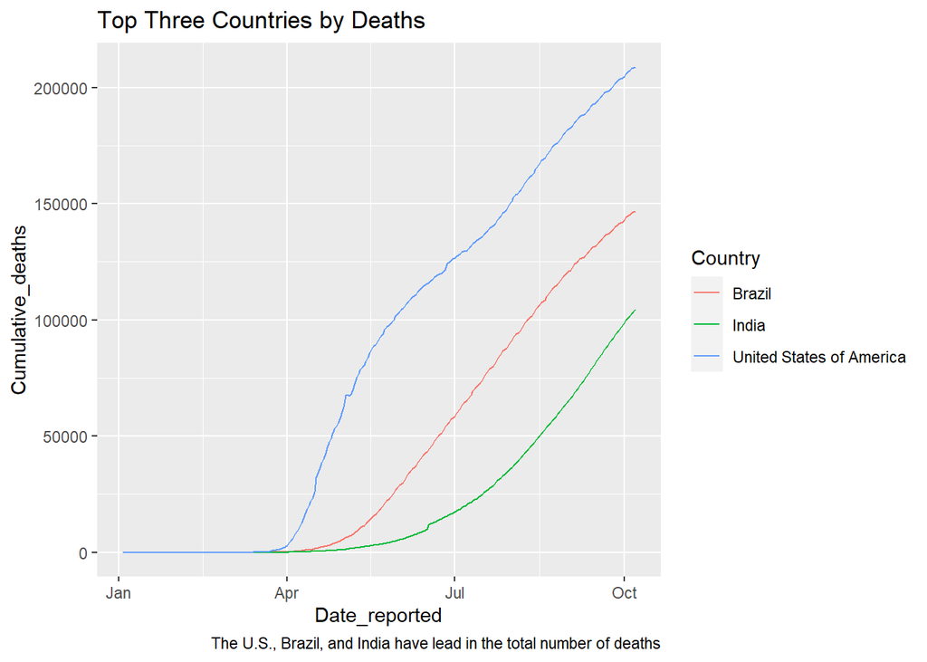

```r
#Filter for top three countries and then make a timeseries (lineplot)
df %>% filter(Country %in% top_three) %>% ggplot(aes(Date_reported,Cumulative_deaths,color=Country))+geom_line()+labs(title="Top Three Countries by Deaths", caption = "The U.S., Brazil, and India have lead in the total number of deaths")
```

3. Create the new variable (column) `death_per_cases` recording the number of deaths per cases (Hint: divide cumulative deaths by cumulative cases). What are the three countries with the highest deaths per cases?

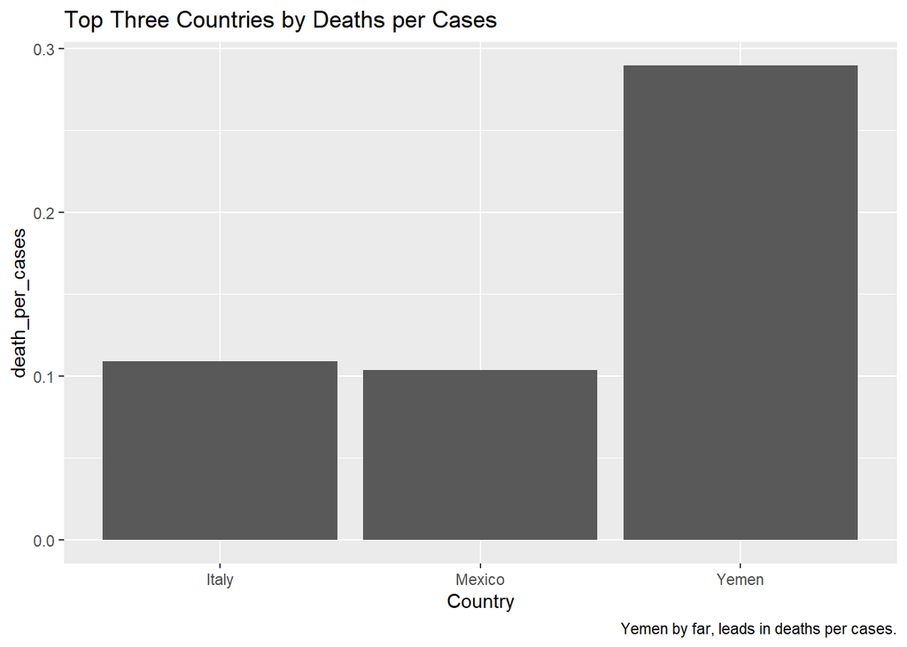

```r
#Create death per cases column
df$death_per_cases <- df$Cumulative_deaths/df$Cumulative_cases

#Sort to find top countries
df1 = df %>% filter(Date_reported == max(Date_reported)) %>% arrange(-death_per_cases)

#Make a col chart to show top three countries
head(df1,3) %>% ggplot(aes(Country,death_per_cases)) + geom_col() + labs(title="Top Three Countries by Deaths per Cases", caption = "Yemen by far, leads in deaths per cases.")
```

4. Make a plot revealing the number of deaths per cases of the US, Italy and Mexico.

[figure not shown]

```r
#Filter for US, Italy and Mexico
top_three = c('United States of America', 'Italy','Mexico')

#This will require gganimate
library(gganimate)

#Filter for for the three countries and plot using the tranisition reveal

df %>% filter(Country %in% top_three) %>% ggplot(aes(Date_reported,Cumulative_deaths,color=Country))+geom_line()+geom_text(aes(label = Cumulative_deaths), hjust = -.1, size=5) +
transition_reveal(Date_reported)+labs(title="U.S., Italy, and Mexico by Total Deaths", caption = "Italy was leading but then topped off around July. The U.S. still continues to rise")
```